# Chapter 5: Clustering

#### Desnity-based clustering

- Flow cytometry datasets w/ few markers but large # cells can under-go density-based clustering
  - Clustering would look for regions of high density separated via sparse regions
  - Can work with non convex clusters
  - ex) dbscan method

```r
mc5 <- Biobase::exprs(fcsBT)[,c(15,16,19,40,33)] #markers into clusters
res5 <- dbscan::dbscan(mc5, eps=0.65, minPts=30)
mc5df <- data.frame(mc5, cluster=as.factor(res5$cluster))
table(mc5df$cluster)
```

```
    0     1     2     3     4     5     6     7     8
75954  4031  5450  5310   259   257    63    25    43
```

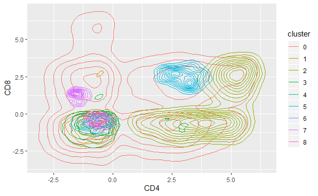

```r
ggplot(mc5df, aes(x=CD4,    y=CD8,  col=cluster))+geom_density2d()
```

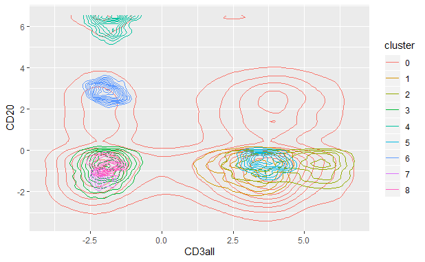

```r
ggplot(mc5df, aes(x=CD3all, y=CD20, col=cluster))+geom_density2d()
```

> results of clustering with dbscan using five markers. Here we only show the projections of the data into the CD4-CD8 and C3all-CD20 planes. - overlaps = show multidimensionality of data
- 17. Increase the dimension to 6 by adding one CD marker-variables form input data
  - Vary eps, & find 4 clusters where >= clusters have more than 100 points
  - Repeat w/ 7 CD marker-variables (what is the difference?)

```r
# 6 marker example
mc6 = Biobase::exprs(fcsBT)[, c(15, 16, 19, 40, 33, 25)] #6 markers
res = dbscan::dbscan(mc6, eps = 0.65, minPts = 20)
mc6df = data.frame(mc6, cluster = as.factor(res$cluster))
table(mc6df$cluster)
```

```
    0     1     2     3     4     5     6
91068    34    61    20    67   121    21
```

Increase #markers = decrease #clusters

```r
# Changing eps= in dbscan()
mc6 = Biobase::exprs(fcsBT)[, c(15, 16, 19, 40, 33, 25)] #6 markers
res = dbscan::dbscan(mc6, eps = 0.55, minPts = 20) #if eps decreased
mc6df = data.frame(mc6, cluster = as.factor(res$cluster))
table(mc6df$cluster)
```

```
    0
91392
```

```r
# Changing eps= in dbscan()
mc6 = Biobase::exprs(fcsBT)[, c(15, 16, 19, 40, 33, 25)] #6 markers
res = dbscan::dbscan(mc6, eps = 0.75, minPts = 20) #if eps increased
mc6df = data.frame(mc6, cluster = as.factor(res$cluster))
table(mc6df$cluster)
```

```
    0     1     2     3     4     5     6     7     8     9    10    11
88650   412   384   733   170   599    20   167   143    27    28    16
   12    13
   23    20
```

Decrease eps = decrease clusters, increase eps = increase clusters

```r
mc7 = Biobase::exprs(fcsBT)[, c(11, 15, 16, 19, 25, 33, 40)] #7 markers/dimensions
res = dbscan::dbscan(mc7, eps = 0.65, minPts = 20) #unchanged eps
mc7df = data.frame(mc7, cluster = as.factor(res$cluster))
table(mc7df$cluster)
```

```
    0
91392
```

```r
mc7 = Biobase::exprs(fcsBT)[, c(11, 15, 16, 19, 25, 33, 40)] #7 markers/dimension
res = dbscan::dbscan(mc7, eps = 0.95, minPts = 20) #increased eps
mc7df = data.frame(mc7, cluster = as.factor(res$cluster))
table(mc7df$cluster)
```

```
    0     1     2     3     4     5     6     7     8     9    10
90249    21   102   445   158   119    19   224    17    20    18
```

- If increased dimensions (#makers), need to increase eps to increase #clusters
  - **This is known as the curse of dimensionality**

  > eps size of the epsilon neighborhood.
- dbscan density-based clustering algorithms
  - Clusters pts in dense regions based on *density-connectedness criteria*
    - Looks for small neighbourhood spheres of radius (ϵ) -> views if points are connected
  - Density-reachability concept
    - point q is density-reachable from point p if not further than a threshold (ϵ)
    - if point p is surrounded by many pts (such that p & q may be part of a dense region) -> then q is density-reachable from p if there is a seq of points p1,…,pn w/ p1=p & p<sub>n</sub>=q -> so each p<sub>i+1</sub> is density-reachable from p<sub>i</sub>
    - Cluster is a subset of points w/ following properties
      1. All pts in clusters are mutually density-connected
      2. If a point is density-connected to any point of cluster, then it is part of the cluster
      3. Groups of points must have MinPts points to count as a cluster

> It is important that the method looks for high density of points in a neighborhood. Other methods exist that try to define clusters by a void, or “missing points” between clusters. But these are vulnerable to the curse of dimensionality; these can create spurious “voids”.

**Hierarchical clustering**<sup>Return</sup>

- This a bottom-up approach (start from obs to infer top/common ancestor)
  - Similar observations & subclasses assembled iteratively
  - ex) Linnaeus nested clusters of organisms based on specific characteristics, seen in below image

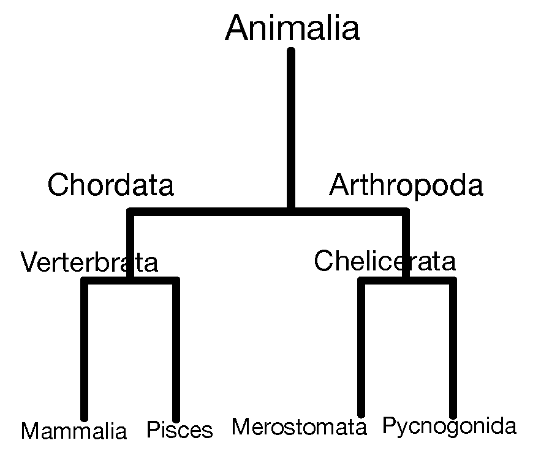

- **Dendogram ordering**
  - Order of labels doesn’t matter within sibling pairs
  - Horizontal distances usually meaningless, vertrical distances have some info for interpretations about neighbours
    - non-monophyletic = not from same subtree/clade -> but can appear as neighbours in a plot (ex) B & D in the below image = non-monophyletic)

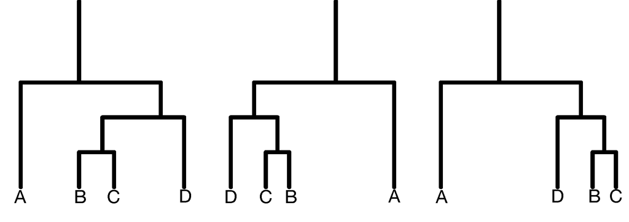

#### Computing (dis)similarities between aggregated clusters

- Hierarchical clustering by aggregation requires more than distances between pairs of individual objects
  - **need to also calculate distances between aggregates**
- How to define aggregates?
  - Based on object-obeject distances -> each choice results in different hieratchical clustering type
- Hierarchical clustering algorithms
  - starts by grouping most similar observations
    - If aggregation occurs -> need to determine what distance between newly formed cluster & all other points OR distance between two clusters
- Choices to build hierarchical clustering trees
  - **Minimal jump & Single Linkage/Nearest neighbour method** = finds distance between two clusters using smallest distance between any 2points in the two cluster
    - This method creates clusters looking like continous strings of points (trees are comb-shaped)

      $$\begin{equation*}
      d_{12} = \min_{i \in C_1, i \in C_2 } d_{ij}.
      \end{equation*}$$

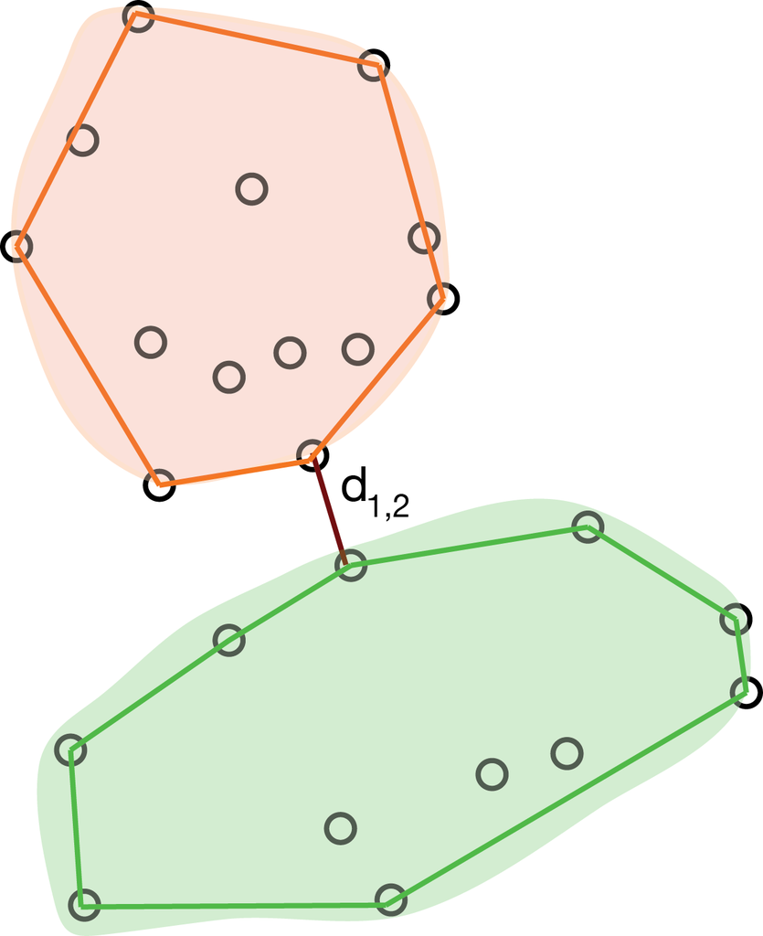

      > In the single linkage method, the distance between groups C1 and C2 is defined as the distance between the closest two points from the groups.
  - **Maximum jump/Complete linkage method** = Defines distance betwen clusters via largest distance between any 2objects in two clusters

    $$\begin{equation*}
    d_{12} = \max_{i \in C_1, i \in C_2 } d_{ij}.
    \end{equation*}$$

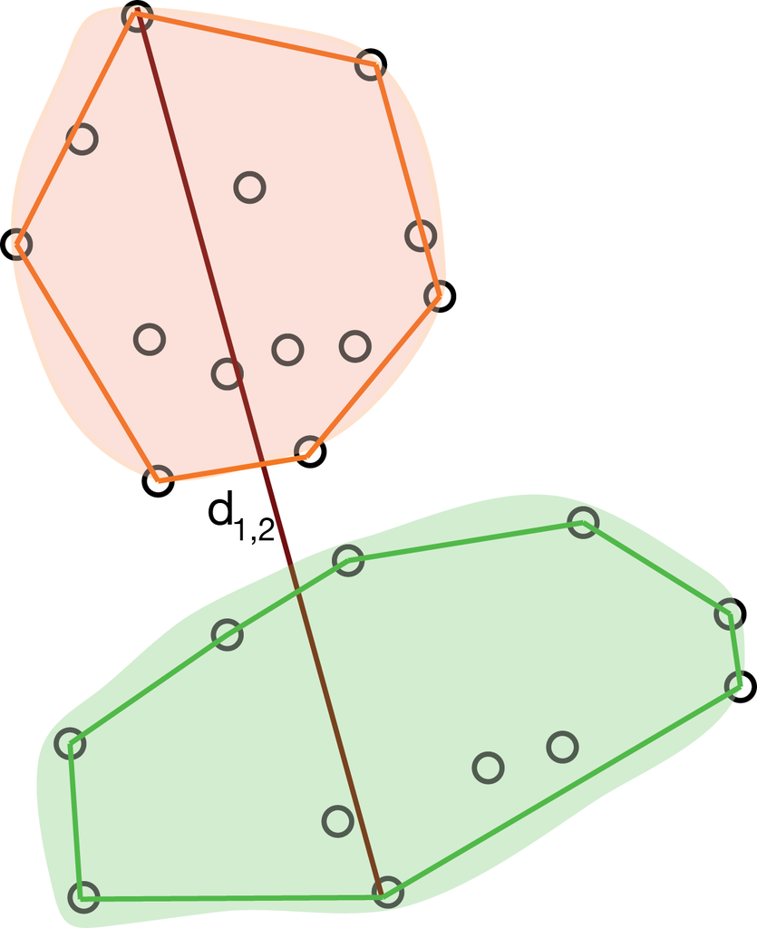

    > In the complete linkage method, the distance between groups C1 and C2 is defined as the maximum distance between pairs of points from the two groups.
  - **Average linkage method** = halfway between the nearest neighbour method & complete linkage method